# Lab 1: Intro to R

### Exercise 4

Present data set info:  
Rows: 63  
Columns: 3  
Variable: year, boys, girls

```r
glimpse(present)
```

```
## Rows: 63
## Columns: 3
## $ year  <dbl> 1940, 1941, 1942, 1943, 1944, 1945, 1946, 1947, 1948, 1949, 1950…
## $ boys  <dbl> 1211684, 1289734, 1444365, 1508959, 1435301, 1404587, 1691220, 1…
## $ girls <dbl> 1148715, 1223693, 1364631, 1427901, 1359499, 1330869, 1597452, 1…
```

### Exercise 5

The magnitudes of the counts aren’t similar.  
For the present’s boys, the counts range from 1,211,684 - 2,186,274,  
while arbuthnot’s ranges from 2890 - 8426

Similar trend within the girls’ counts too:  
present: 1,148,715 - 2,082,052  
arbuthnot: 2722 - 7779

```r
present |> summarise(min = min(boys), max = max(boys))
```

```
## # A tibble: 1 × 2
##       min     max
##     <dbl>   <dbl>
## 1 1211684 2186274
```

```r
arbuthnot |> summarise(min = min(boys), max = max(boys))
```

```
## # A tibble: 1 × 2
##     min   max
##   <int> <int>
## 1  2890  8426
```

```r
present |> summarise(min = min(girls), max = max(girls))
```

```
## # A tibble: 1 × 2
##       min     max
##     <dbl>   <dbl>
## 1 1148715 2082052
```

```r
arbuthnot |> summarise(min = min(girls), max = max(girls))
```

```
## # A tibble: 1 × 2
##     min   max
##   <int> <int>
## 1  2722  7779
```

### Exercise 6

Arbuthnot’s observation about boys being born in greater proportion that girls hold up in the US present’s dataset.

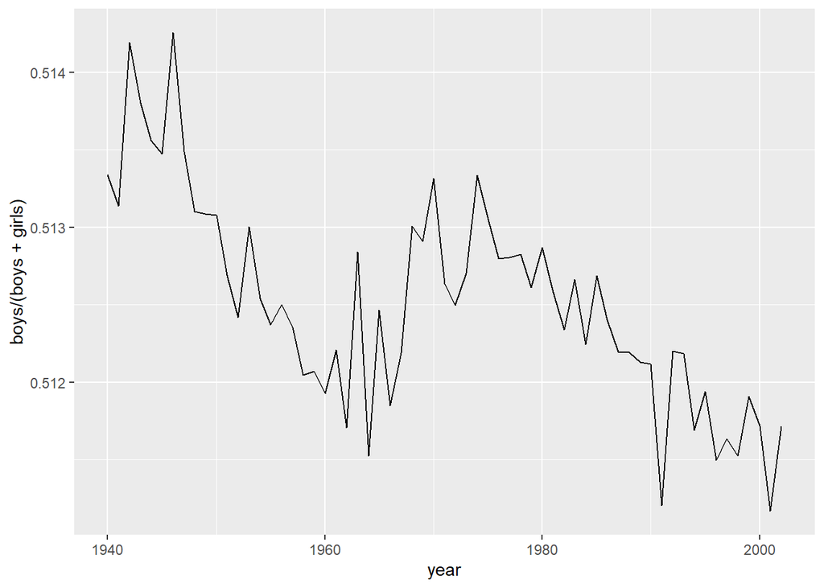

```r
ggplot(data = present, aes(x = year, y = boys/(boys + girls))) + geom_line()
```

### Exercise 7

1961 has the most total number of births in US

```r
present <- present |> mutate(total = boys + girls)
rearrange <- present |> arrange(desc(total))
View(rearrange)
```